# Report

2026-10-31

```r
library(readr)
library(dplyr)
library(stringr)
library(tidyverse)
library(here)
library(mgcv)
```

```r
library(ggplot2)
library(emmeans)
library(ggeffects)
library(car)
library(knitr)
```

## Data cleaning

```r
df1 <- read.csv(here("data", "AHSnhs11bsp.csv"), stringsAsFactors = TRUE)
df2 <- read.csv(here("data", "AHSnhs11bbi.csv"), stringsAsFactors = TRUE)

df <- df1 %>%
  dplyr::select(ABSLID, ABSPID, SEX, SMKSTAT, ALCF3, AGEB, ALINWKSD, FEMLSBC) %>%
  filter(!(ABSLID == "NHS11B0009794" & ABSPID == 6)) %>%
  left_join(
      df2 %>%
      filter(!(ABSLID == "NHS11B0009794" & ABSPID == 6)) %>%
      dplyr::select(ABSLID, ABSPID, EGFRKDSA, DIABPRVE),
      by = c("ABSLID", "ABSPID")
    )
```

```r
ckd_data <- df %>%
  mutate(
    age = case_when(
      AGEB %in% 1:4 ~ NA_real_,
      AGEB == 5 ~ 18.5,
      AGEB == 6 ~ 22,
      AGEB == 7 ~ 27,
      AGEB == 8 ~ 32,
      AGEB == 9 ~ 37,
      AGEB == 10 ~ 42,
      AGEB == 11 ~ 47,
      AGEB == 12 ~ 52,
      AGEB == 13 ~ 57,
      AGEB == 14 ~ 62,
      AGEB == 15 ~ 67,
      AGEB == 16 ~ 72,
      AGEB == 17 ~ 77,
      AGEB == 18 ~ 82,
      AGEB == 19 ~ 85,
    ),
    sex = case_when(
      SEX == 1 ~ "Male",
      SEX == 2 ~ "Female",
    ),
    ckd = case_when(
      EGFRKDSA == 1 ~ "No CKD",
      EGFRKDSA %in% 2:6 ~ "CKD",
      EGFRKDSA %in% c(0, 8) ~ NA_character_
    ),
    smoker_status = case_when(
      SMKSTAT == 5 ~ "Never smoked",
      SMKSTAT == 4 ~ "Ex-smoker",
      SMKSTAT %in% c(1, 2, 3) ~ "Current smoker",
      SMKSTAT == 0 ~ NA_character_
    ),
    alcohol_frequency = case_when(
      ALCF3 == 1 ~ 7,
      ALCF3 == 2 ~ 6,
      ALCF3 == 3 ~ 5,
      ALCF3 == 4 ~ 4,
      ALCF3 == 5 ~ 3,
      ALCF3 == 6 ~ 2,
      ALCF3 == 7 ~ 1,
      ALCF3 == 98 ~ NA_real_,
      ALCF3 == 97 ~ NA_real_,
      ALCF3 == 99 ~ NA_real_,
      ALCF3 %in% c(0, 8, 9, 10) ~ 0
    ), #How many days a week, that they drink three or more standards, over the last year
    alcohol_quantity = case_when(
      ALINWKSD == 97 ~ 0,
      ALINWKSD >= 0 & ALINWKSD <= 96 ~ ALINWKSD,
      ALINWKSD %in% c(98, 99) ~ NA_real_
    ),
    diabetes = case_when(
      DIABPRVE %in% c(0, 8) ~ NA_real_,
      DIABPRVE %in% c(1, 2) ~ 1,
      DIABPRVE %in% c(3, 4) ~ 0
    ),
    menopause = case_when(
      FEMLSBC %in% c(1:4, 6) ~ 0,
      FEMLSBC == 5 ~ 1,
      FEMLSBC == 9 ~ 2
    )
  )
```

```r
alcohol_type <- read.csv(here("data", "AHSnhs11b14.csv"), stringsAsFactors = TRUE) %>%
  dplyr::select(
    ABSLID,
    ABSPID,
    ABSBID,
    ABSTID,
    ALCTYPT,
  )
```

```r
alcohol_type <- alcohol_type %>%
  mutate(
    alcohol_type = case_when(
      ALCTYPT == 1 ~ "low_alcohol_beer",
      ALCTYPT == 2 ~ "mid_strength_beer",
      ALCTYPT == 3 ~ "full_strength_beer",
      ALCTYPT == 4 ~ "white_wine",
      ALCTYPT == 5 ~ "red_wine",
      ALCTYPT == 6 ~ "low_alcohol_wine",
      ALCTYPT == 7 ~ "champagne_sparkling_wine",
      ALCTYPT == 8 ~ "spirits_rtd",
      ALCTYPT == 9 ~ "liqueurs",
      ALCTYPT == 10 ~ "spirits",
      ALCTYPT == 11 ~ "fortified_wine",
      ALCTYPT == 12 ~ "cider",
      ALCTYPT == 13 ~ "cocktails",
      ALCTYPT == 14 ~ "other",
      ALCTYPT == 0 ~ NA_character_
    )
  )
```

```r
# Keep one record for each participant and alcohol type
alcohol_type_person <- alcohol_type %>%
  filter(!is.na(alcohol_type)) %>%
  distinct(ABSLID, ABSPID, alcohol_type) %>%
  mutate(value = 1) %>%
  pivot_wider(
    names_from = alcohol_type,
    values_from = value,
    values_fill = 0
  )
```

```r
# Combine alcohol type and alcohol quantity at the participant level
df_final <- ckd_data %>%
  left_join(
    alcohol_type_person,
    by = c("ABSLID", "ABSPID")
  )
```

```r
df_filter <- df_final %>%
  filter(
    !is.na(sex),
    !is.na(ckd),
    !is.na(alcohol_quantity),
    !is.na(red_wine),
    !is.na(alcohol_frequency),
    !is.na(age),
    !is.na(smoker_status),
    !is.na(diabetes),
    age >= 35
  ) %>%
  mutate(
    ckd = factor(
      ifelse(ckd == "CKD", 1, 0),
      levels = c(0, 1)
    ),
    sex = factor(
      sex,
      levels = c("Female", "Male")
    ),
    smoker_status = factor(
      smoker_status,
      levels = c(
        "Current smoker",
        "Ex-smoker",
        "Never smoked"
      )
    ),
    diabetes = factor(
      diabetes,
      levels = c(0, 1)
    ),
    menopause = factor(
      menopause,
      levels = c(0, 1, 2)
    ),
    across(
      c(
        low_alcohol_beer,
        mid_strength_beer,
        full_strength_beer,
        white_wine,
        red_wine,
        low_alcohol_wine,
        champagne_sparkling_wine,
        spirits_rtd,
        liqueurs,
        spirits,
        fortified_wine,
        cider,
        cocktails
      ),
      ~ factor(.x, levels = c(0, 1), labels = c(0, 1))
    )
  )
```

```r
saveRDS(df_filter, "shared_df_filter.rds")
```

## Logistic regression

```r
ckd_data <- df_filter %>%
  mutate(
    beer = factor(
      as.character(low_alcohol_beer) == "1" |
      as.character(mid_strength_beer) == "1" |
      as.character(full_strength_beer) == "1",
      levels = c(FALSE, TRUE),
      labels = c("0", "1")
    ),

    wine = factor(
      as.character(white_wine) == "1" |
      as.character(red_wine) == "1" |
      as.character(low_alcohol_wine) == "1" |
      as.character(champagne_sparkling_wine) == "1" |
      as.character(fortified_wine) == "1",
      levels = c(FALSE, TRUE),
      labels = c("0", "1")
    ),

    spirits_liqueurs = factor(
      as.character(spirits_rtd) == "1" |
      as.character(liqueurs) == "1" |
      as.character(spirits) == "1",
      levels = c(FALSE, TRUE),
      labels = c("0", "1")
    )
  ) %>%
  dplyr::select(
    -low_alcohol_beer,
    -mid_strength_beer,
    -full_strength_beer,
    -white_wine,
    -red_wine,
    -low_alcohol_wine,
    -champagne_sparkling_wine,
    -fortified_wine,
    -spirits_rtd,
    -liqueurs,
    -spirits
  )
```

### Alcohol quantity

```r
model_int <- glm(ckd ~ age + alcohol_quantity * sex + alcohol_frequency + diabetes + beer + wine + spirits_liqueurs + cider + cocktails, data = ckd_data, family = binomial)
```

#### Results

```r
model_summary <- summary(model_int)$coefficients

results_pretty <- data.frame(
  Variable = rownames(model_summary),

  OR = exp(model_summary[, "Estimate"]),

  `95% CI` = paste0(
    sprintf("%.2f", exp(model_summary[, "Estimate"] -
                         1.96 * model_summary[, "Std. Error"])),
    "–",
    sprintf("%.2f", exp(model_summary[, "Estimate"] +
                         1.96 * model_summary[, "Std. Error"]))
  ),

  `P-value` = ifelse(
    model_summary[, "Pr(>|z|)"] < 0.001,
    "<0.001",
    sprintf("%.3f", model_summary[, "Pr(>|z|)"])
  ),

  check.names = FALSE
)

results_pretty$OR <- sprintf("%.2f", results_pretty$OR)

print(results_pretty, row.names = FALSE)
```

```
##                  Variable   OR    95% CI P-value
##               (Intercept) 0.00 0.00–0.00  <0.001
##                       age 1.08 1.07–1.09  <0.001
##          alcohol_quantity 0.84 0.70–1.02   0.079
##                   sexMale 1.22 0.83–1.78   0.309
##         alcohol_frequency 1.02 0.94–1.10   0.646
##                 diabetes1 2.24 1.51–3.32  <0.001
##                     beer1 0.95 0.68–1.33   0.763
##                     wine1 0.92 0.66–1.26   0.588
##         spirits_liqueurs1 0.92 0.66–1.27   0.605
##                    cider1 0.76 0.26–2.17   0.603
##                cocktails1 1.25 0.16–9.91   0.830
##  alcohol_quantity:sexMale 1.22 1.01–1.47   0.042
```

Forest plot: all variables

```
## `height` was translated to `width`.
```

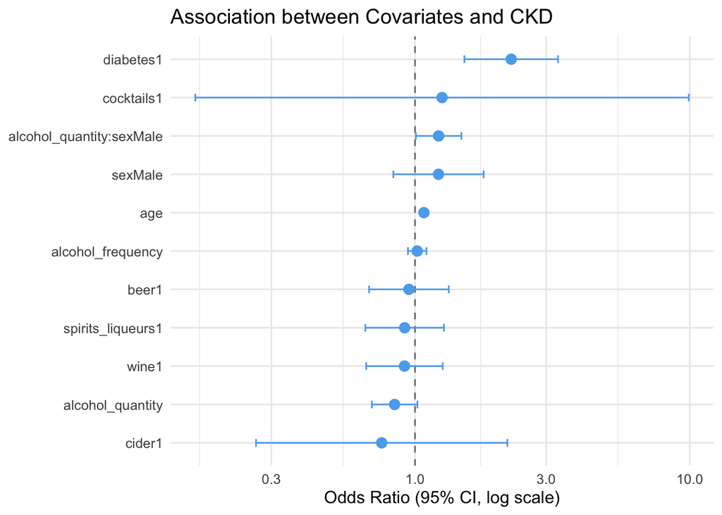

```r
plot_data <- data.frame(
  Variable = rownames(model_summary),
  OR = exp(model_summary[, "Estimate"]),
  Lower = exp(model_summary[, "Estimate"] -
                1.96 * model_summary[, "Std. Error"]),
  Upper = exp(model_summary[, "Estimate"] +
                1.96 * model_summary[, "Std. Error"]),
  p_value = model_summary[, "Pr(>|z|)"]
)

plot_data <- subset(plot_data, Variable != "(Intercept)")

ggplot(plot_data,
       aes(x = OR, y = reorder(Variable, OR))) +
  geom_vline(xintercept = 1, linetype = "dashed",
             color = "grey50") +
  geom_errorbarh(aes(xmin = Lower, xmax = Upper),
                 height = 0.2, color = "steelblue2") +
  geom_point(size = 3, color = "steelblue2") +
  scale_x_log10() +
  labs(
    title = "Association between Covariates and CKD",
    x = "Odds Ratio (95% CI, log scale)",
    y = NULL
  ) +
  theme_minimal(base_size = 12)
```

Forest plot: compare genders

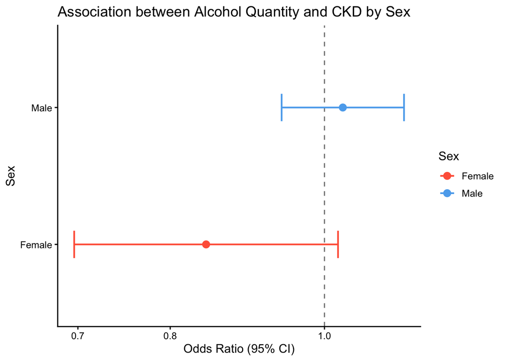

```r
b <- coef(model_int)
V <- vcov(model_int)

beta_female <- b["alcohol_quantity"]

se_female <- sqrt(
  V["alcohol_quantity", "alcohol_quantity"]
)

beta_male <- b["alcohol_quantity"] +
  b["alcohol_quantity:sexMale"]

se_male <- sqrt(
  V["alcohol_quantity", "alcohol_quantity"] +
  V["alcohol_quantity:sexMale",
    "alcohol_quantity:sexMale"] +
  2 * V["alcohol_quantity",
        "alcohol_quantity:sexMale"]
)

plot_interaction <- data.frame(
  Sex = c("Female", "Male"),
  OR = exp(c(beta_female, beta_male)),
  Lower = exp(c(
    beta_female - 1.96 * se_female,
    beta_male - 1.96 * se_male
  )),
  Upper = exp(c(
    beta_female + 1.96 * se_female,
    beta_male + 1.96 * se_male
  ))
)

ggplot(plot_interaction,
       aes(x = OR, y = Sex, color = Sex)) +
  geom_vline(
    xintercept = 1,
    linetype = "dashed",
    color = "grey50"
  ) +
  geom_errorbar(
    aes(xmin = Lower, xmax = Upper),
    orientation = "y",
    width = 0.2,
    linewidth = 0.8
  ) +
  geom_point(size = 3) +
  scale_color_manual(
    values = c(
      "Male" = "steelblue2",
      "Female" = "tomato1"
    )
  ) +
  scale_x_log10() +
  labs(
    title = "Association between Alcohol Quantity and CKD by Sex",
    x = "Odds Ratio (95% CI)",
    y = "Sex",
    color = "Sex"
  ) +
  theme_classic(base_size = 12)
```

Effect Plot

```r
effect_data <- ggpredict(
  model_int,
  terms = c("alcohol_quantity", "sex")
)
```

```
## Data were 'prettified'. Consider using `terms="alcohol_quantity [all]"`
##   to get smooth plots.
```

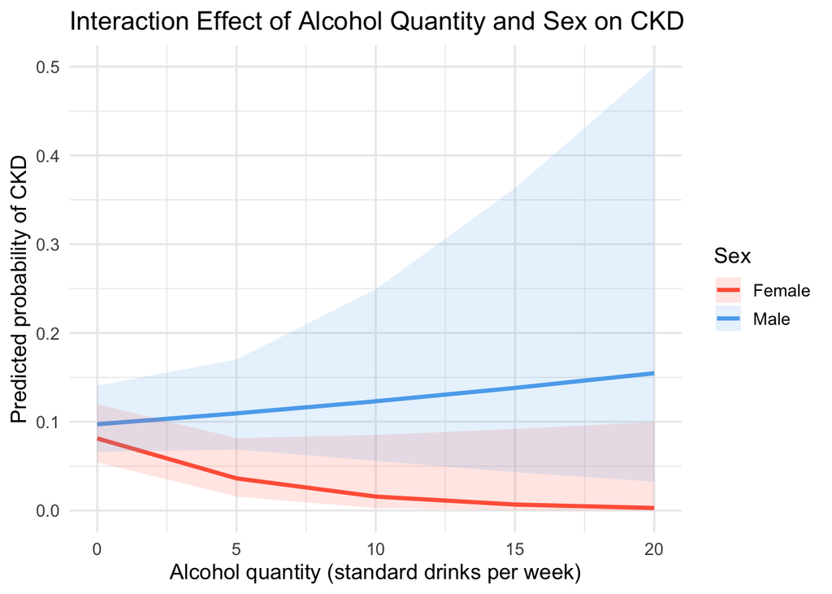

```r
ggplot(effect_data, aes(x = x, y = predicted,
                        colour = group, fill = group)) +
  geom_line(linewidth = 1.2) +
  geom_ribbon(aes(ymin = conf.low, ymax = conf.high),
              alpha = 0.15, colour = NA) +

  scale_colour_manual(
    values = c("Female" = "tomato1",
               "Male" = "steelblue2")
  ) +

  scale_fill_manual(
    values = c("Female" = "tomato1",
               "Male" = "steelblue2")
  ) +

  labs(
    x = "Alcohol quantity (standard drinks per week)",
    y = "Predicted probability of CKD",
    colour = "Sex",
    fill = "Sex",
    title = "Interaction Effect of Alcohol Quantity and Sex on CKD"
  ) +
  theme_minimal(base_size = 13)
```

## GAM (alcohol only)

```r
# Main model: separate alcohol curves by sex, adjusted for all confounders
fit <- gam(
  ckd ~ age + sex + s(alcohol_quantity, by = sex, k = 5) +
    alcohol_frequency + diabetes + beer + wine + spirits_liqueurs +
    cider + cocktails,
  data = ckd_data, family = binomial(), method = "REML"
)

# Test sex modification: same participants and covariates in both models
separate_ml <- update(fit, method = "ML")
shared_ml <- update(
  separate_ml, . ~ . - s(alcohol_quantity, by = sex, k = 5) +
    s(alcohol_quantity, k = 5)
)
comparison <- anova(shared_ml, separate_ml, test = "Chisq")

# Manuscript results
ckd <- model.response(model.frame(fit))
c(participants = nobs(fit), CKD_cases = sum(ckd == "1"))
```

```
## participants    CKD_cases
##         2762          312
```

```r
knitr::kable(summary(fit)$s.table[, c("edf", "p-value"), drop = FALSE],
             digits = 3, caption = "Adjusted alcohol association within each sex.")
```

Adjusted alcohol association within each sex.

|  | edf | p-value |
| --- | --- | --- |
| s(alcohol_quantity):sexFemale | 1.000 | 0.079 |
| s(alcohol_quantity):sexMale | 1.001 | 0.558 |

```r
comparison
```

```
## Analysis of Deviance Table
##
## Model 1: ckd ~ age + sex + alcohol_frequency + diabetes + beer + wine +
##     spirits_liqueurs + cider + cocktails + s(alcohol_quantity,
##     k = 5)
## Model 2: ckd ~ age + sex + s(alcohol_quantity, by = sex, k = 5) + alcohol_frequency +
##     diabetes + beer + wine + spirits_liqueurs + cider + cocktails
##   Resid. Df Resid. Dev Df Deviance Pr(>Chi)
## 1      2751     1681.0
## 2      2750     1676.4  1   4.6438  0.03117 *
## ---
## Signif. codes:  0 '***' 0.001 '**' 0.01 '*' 0.05 '.' 0.1 ' ' 1
```

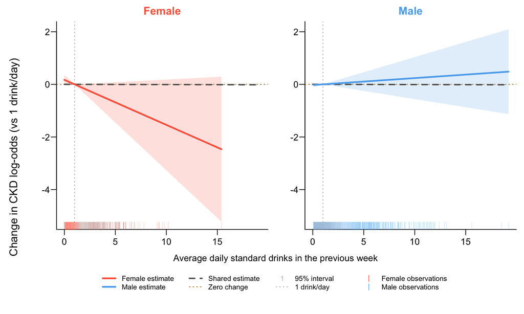

```r
summary(fit)$s.table[, c("edf", "p-value"), drop = FALSE]
```

```
##                                    edf   p-value
## s(alcohol_quantity):sexFemale 1.000215 0.0786721
## s(alcohol_quantity):sexMale   1.000933 0.5576890
```

Testing for basis dimension

```r
fit_k10 <- update(
  fit,
  . ~ . - s(alcohol_quantity, by = sex, k = 5) +
          s(alcohol_quantity, by = sex, k = 10),
  data = model.frame(fit)
)

# Largest absolute change in fitted CKD probability, in percentage points
100 * max(abs(fitted(fit_k10) - fitted(fit)))
```

```
## [1] 0.001043894
```

#### Assumptions and Diagnostics

Checking linearity: scatter plots with LOWESS smoothing curves

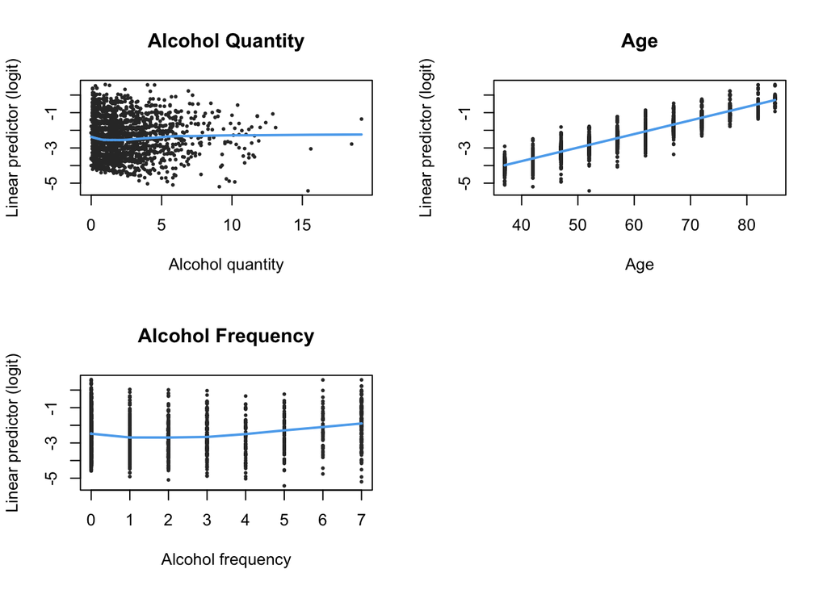

Multicollinearity: variance inflation factors

```r
round(vif(model_int), 2)
```

```
##                  age     alcohol_quantity                  sex
##                 1.04                10.93                 2.16
##    alcohol_frequency             diabetes                 beer
##                 2.10                 1.03                 1.74
##                 wine     spirits_liqueurs                cider
##                 1.53                 1.19                 1.02
##            cocktails alcohol_quantity:sex
##                 1.01                12.01
```

A model without the interaction term was fitted to compare

```r
model_no_int <- glm(ckd ~ age + alcohol_quantity + sex + alcohol_frequency + diabetes + beer + wine + spirits_liqueurs + cider + cocktails, data = ckd_data, family = binomial)
round(vif(model_no_int), 2)
```

```
##               age  alcohol_quantity               sex alcohol_frequency
##              1.04              2.15              1.32              2.05
##          diabetes              beer              wine  spirits_liqueurs
##              1.03              1.72              1.53              1.18
##             cider         cocktails
##              1.02              1.01
```

Influential observations: Cook’s distance

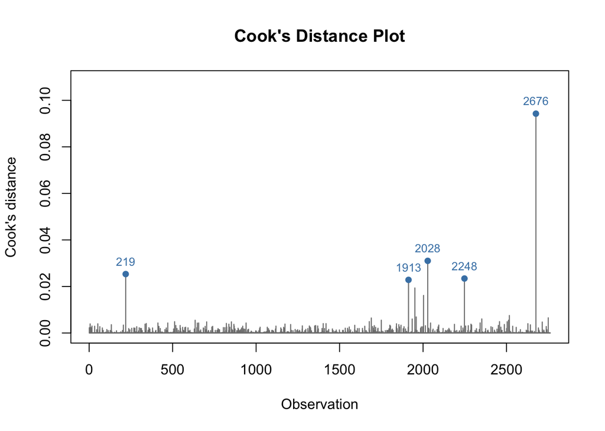

```r
cd <- cooks.distance(model_int)
top5 <- order(cd, decreasing = TRUE)[1:5]

plot(
  1:length(cd), cd,
  type = "h",
  col = "gray50",
  lwd = 1.2,
  xlab = "Observation",
  ylab = "Cook's distance",
  main = "Cook's Distance Plot",
  ylim = c(0, max(cd) * 1.15)
)

points(
  top5,
  cd[top5],
  col = "steelblue",
  pch = 16,
  cex = 1
)

text(
  top5,
  cd[top5],
  labels = top5,
  pos = 3,
  col = "steelblue",
  cex = 0.8
)
```

```r
top7_cd <- sort(cd, decreasing = TRUE)[1:7]
round(top7_cd, 4)
```

```
##   2676   2028    219   2248   1913   1951   2003
## 0.0943 0.0310 0.0253 0.0234 0.0228 0.0194 0.0161
```

```r
top7 <- order(cd, decreasing = TRUE)[1:7]
data.frame(
  Observation = top7,
  Cooks_Distance = round(cd[top7], 4),
  ckd_data[top7, c(
    "ckd",
    "age",
    "alcohol_quantity",
    "sex",
    "alcohol_frequency",
    "diabetes",
    "beer",
    "wine",
    "spirits_liqueurs",
    "cider",
    "cocktails"
  )]
)
```

```
##      Observation Cooks_Distance ckd age alcohol_quantity    sex
## 2676        2676         0.0943   1  37              7.7   Male
## 2028        2028         0.0310   1  42             18.5   Male
## 219          219         0.0253   1  42              0.4 Female
## 2248        2248         0.0234   1  52              0.4 Female
## 1913        1913         0.0228   1  52              0.9   Male
## 1951        1951         0.0194   1  72              0.3 Female
## 2003        2003         0.0161   1  72              5.8 Female
##      alcohol_frequency diabetes beer wine spirits_liqueurs cider cocktails
## 2676                 4        0    1    0                1     0         1
## 2028                 7        0    1    0                0     0         0
## 219                  0        0    0    0                1     1         0
## 2248                 0        0    0    1                0     1         0
## 1913                 0        0    0    0                0     1         0
## 1951                 0        0    0    0                0     1         0
## 2003                 7        0    1    1                0     0         0
```

### Smoking

```r
# no smoking, model 1, reduced
model_smoking_reduced <- glm(ckd ~ age + sex + diabetes, data = ckd_data, family = binomial)

# smoking + sex, model 2, additive
model_smoking_additive <- glm(ckd ~ age + smoker_status + sex + diabetes, data = ckd_data, family = binomial)

# model 3, interaction
model_smoking_interaction <- glm(ckd ~ age + smoker_status * sex + diabetes, data = ckd_data, family = binomial)
```

LRT between model 1 and model 2: Smoking overall association

```r
anova(model_smoking_reduced, model_smoking_additive, test = "LRT")
```

```
## Analysis of Deviance Table
##
## Model 1: ckd ~ age + sex + diabetes
## Model 2: ckd ~ age + smoker_status + sex + diabetes
##   Resid. Df Resid. Dev Df Deviance Pr(>Chi)
## 1      2758     1682.1
## 2      2756     1680.8  2   1.2184   0.5438
```

LRT between model 2 and model 3: Whether sex modifies the association

```r
anova(model_smoking_additive, model_smoking_interaction, test = "LRT")
```

```
## Analysis of Deviance Table
##
## Model 1: ckd ~ age + smoker_status + sex + diabetes
## Model 2: ckd ~ age + smoker_status * sex + diabetes
##   Resid. Df Resid. Dev Df Deviance Pr(>Chi)
## 1      2756     1680.8
## 2      2754     1679.4  2   1.4113   0.4938
```

### Menopause

```r
ckd_data_menopausewomen_men <- ckd_data %>%
  filter(
    !menopause == "0"
      )
```

```r
model_menopausewomenmen <- glm(ckd ~ age + alcohol_quantity * sex + alcohol_frequency + diabetes + beer + wine + spirits_liqueurs + cider + cocktails, data = ckd_data_menopausewomen_men, family = binomial)

model_menopausesummary <- summary(model_menopausewomenmen)$coefficients

results_pretty_menopause <- data.frame(
  Variable = rownames(model_menopausesummary),

  OR = exp(model_menopausesummary[, "Estimate"]),

  `95% CI` = paste0(
    sprintf("%.2f", exp(model_menopausesummary[, "Estimate"] -
                         1.96 * model_menopausesummary[, "Std. Error"])),
    "–",
    sprintf("%.2f", exp(model_menopausesummary[, "Estimate"] +
                         1.96 * model_menopausesummary[, "Std. Error"]))
  ),

  `P-value` = ifelse(
    model_menopausesummary[, "Pr(>|z|)"] < 0.001,
    "<0.001",
    sprintf("%.3f", model_menopausesummary[, "Pr(>|z|)"])
  ),

  check.names = FALSE
)

results_pretty_menopause$OR <- sprintf("%.2f", results_pretty_menopause$OR)

print(results_pretty_menopause, row.names = FALSE)
```

```
##                  Variable   OR     95% CI P-value
##               (Intercept) 0.00  0.00–0.00  <0.001
##                       age 1.09  1.07–1.10  <0.001
##          alcohol_quantity 0.88  0.69–1.12   0.302
##                   sexMale 1.40  0.88–2.23   0.151
##         alcohol_frequency 1.03  0.95–1.11   0.539
##                 diabetes1 2.04  1.34–3.11  <0.001
##                     beer1 1.04  0.73–1.50   0.824
##                     wine1 0.91  0.65–1.29   0.614
##         spirits_liqueurs1 0.92  0.64–1.33   0.656
##                    cider1 0.43  0.10–1.84   0.257
##                cocktails1 2.30 0.26–20.52   0.454
##  alcohol_quantity:sexMale 1.16  0.91–1.48   0.232
```

## Method Descriptive Summaries

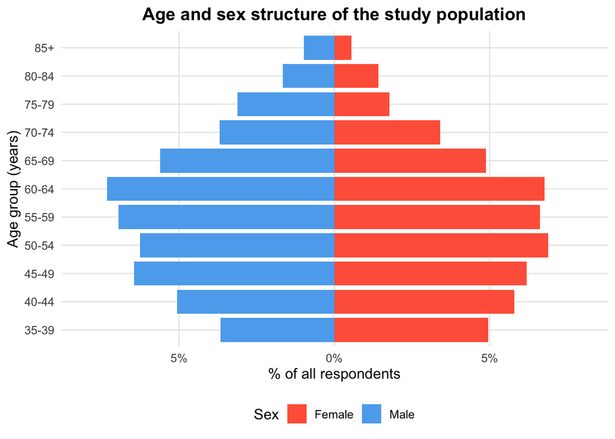

```r
age_labels <- c("35-39", "40-44", "45-49", "50-54", "55-59", "60-64",
                "65-69", "70-74", "75-79", "80-84", "85+")

plot_data <- df_filter %>%
  mutate(
    AgeGroup = cut(age,
                   breaks = c(34, 39, 44, 49, 54, 59, 64, 69, 74, 79, 84, Inf),
                   labels = age_labels, right = TRUE),
    Sex = factor(sex)
  ) %>%
  filter(!is.na(AgeGroup)) %>%
  count(Sex, AgeGroup) %>%
  mutate(
    Proportion     = n / sum(n),
    PlotProportion = ifelse(Sex == "Male", -Proportion, Proportion)
  )

lim <- ceiling(max(plot_data$Proportion) * 100) / 100   # symmetric axis from the data

p_pyramid <- ggplot(plot_data, aes(x = AgeGroup, y = PlotProportion, fill = Sex)) +
  geom_col(width = 0.85) +
  coord_flip() +
  scale_y_continuous(
    labels = function(x) paste0(abs(x) * 100, "%"),
    limits = c(-lim, lim)
  ) +
  scale_fill_manual(values = c("Male" = "steelblue2", "Female" = "tomato1")) +
  labs(
    title = "Age and sex structure of the study population",
    x = "Age group (years)",
    y = "% of all respondents",
    fill = "Sex"
  ) +
  theme_minimal(base_size = 12) +
  theme(
    plot.title = element_text(face = "bold", hjust = 0.5),
    panel.grid.minor = element_blank(),
    legend.position = "bottom"
  )

p_pyramid
```

```r
ggsave(here("figures", "age_sex_pyramid.png"), plot = p_pyramid,
       width = 7, height = 5, dpi = 300)
```

## XGBoost

```r
# install.packages(c("xgboost", "dplyr", "tidyr", "ggplot2", "here", "knitr"))
library(xgboost)
library(dplyr)
library(tidyr)
library(ggplot2)
library(here)
library(knitr)

set.seed(2026)   # same seed as the standalone XGBoost Rmds
# ---- switches ---------------------------------------------------------------
data_file  <- here("report", "shared_df_filter.rds")   # shared report data; here() finds it from the project root
save_folds <- FALSE   # TRUE writes Rcode/cv_folds_ckd.rds so the random forest can reuse identical folds
n_rep      <- 5       # repeats of stratified k-fold CV
k_fold     <- 5
n_threads  <- 2
```

### Aim

Use gradient-boosted trees (XGBoost) to ask two questions about CKD in adults aged 35+:

1. Does alcohol intake help predict CKD, and **does sex modify that relationship**?
2. Secondary: does sex modify the **smoking**–CKD relationship?

XGBoost can pick up non-linear effects and interactions that the logistic regression and GAM cannot, so it is used here as a flexible check on those models. All results are **associations**, not causal effects.

### 1. Data

```r
df <- readRDS(data_file)

# Outcome: CKD = 1 if EGFRKDSA stage 1-6, 0 if no indicators of CKD
y <- as.integer(as.character(df$ckd))

# Predictors. Everything is numeric so SHAP values are easy to read.
as01 <- function(f) as.integer(as.character(f))

bev_cols <- c("low_alcohol_beer", "mid_strength_beer", "full_strength_beer",
              "white_wine", "red_wine", "low_alcohol_wine",
              "champagne_sparkling_wine", "spirits_rtd", "liqueurs",
              "spirits", "fortified_wine", "cider", "cocktails")

X <- data.frame(
  male             = as.integer(df$sex == "Male"),
  AGE              = df$age,
  alcohol_quantity = df$alcohol_quantity,   # std drinks/day, last week
  ALC_freq_3       = df$alcohol_frequency,         # ordinal survey code, days with 3+ drinks in past year
  smoker_current   = as.integer(df$smoker_status == "Current smoker"),
  smoker_ex        = as.integer(df$smoker_status == "Ex-smoker"),
  diabetes         = as01(df$diabetes)          # self-reported diabetes diagnosis (1 = yes)
)
X[bev_cols] <- lapply(df[bev_cols], as01)
X <- as.matrix(X)

alc_vars   <- c("alcohol_quantity", "ALC_freq_3", bev_cols)
smoke_vars <- c("smoker_current", "smoker_ex")

# Columns that must NOT be predictors:
#  - eGFR_range: CKD is defined from eGFR/ACR, so it leaks the outcome
#    (every person with eGFR < 60 is coded CKD).
#  - Alcohol_risk / Alcohol_risk_7day: derived from alcohol_quantity.
stopifnot(!any(c("eGFR_range", "Alcohol_risk", "Alcohol_risk_7day") %in% colnames(X)))
stopifnot(!anyNA(X), !anyNA(y), all(y %in% 0:1))

# Plot labels, capitalised to match the other models' figures
labels <- c(AGE = "Age", male = "Sex", diabetes = "Diabetes",
            alcohol_quantity = "Alcohol Quantity",
            ALC_freq_3 = "Alcohol Frequency",
            low_alcohol_beer = "Low Alcohol Beer", mid_strength_beer = "Mid Strength Beer",
            full_strength_beer = "Full Strength Beer", white_wine = "White Wine",
            red_wine = "Red Wine", low_alcohol_wine = "Low Alcohol Wine",
            champagne_sparkling_wine = "Champagne and Sparkling Wine",
            spirits_rtd = "Pre-mixed Spirits", liqueurs = "Liqueurs",
            spirits = "Spirits", fortified_wine = "Fortified Wine",
            cider = "Cider", cocktails = "Cocktails",
            smoker_current = "Current Smoker", smoker_ex = "Ex-Smoker")

# Order for the importance plot: demographics and health first, then alcohol, then smoking
var_order <- c("AGE", "male", "diabetes", "alcohol_quantity", "ALC_freq_3", bev_cols,
               "smoker_current", "smoker_ex")

# Sex colours shared with the random forest figures
sex_cols <- c(Female = "tomato", Male = "steelblue")

sample_tab <- data.frame(
  Group = c("All", "Female", "Male"),
  n     = c(length(y), sum(X[, "male"] == 0), sum(X[, "male"] == 1)),
  CKD   = c(sum(y), sum(y[X[, "male"] == 0]), sum(y[X[, "male"] == 1]))
)
sample_tab$`CKD %` <- round(100 * sample_tab$CKD / sample_tab$n, 1)
kable(sample_tab, caption = "Analysis sample: adults aged 35+ with complete data (shared_df_filter.rds).")
```

Analysis sample: adults aged 35+ with complete data (shared_df_filter.rds).

| Group | n | CKD | CKD % |
| --- | --- | --- | --- |
| All | 2762 | 312 | 11.3 |
| Female | 1360 | 112 | 8.2 |
| Male | 1402 | 200 | 14.3 |

**Sample note.** The shared data frame only keeps people with a recorded beverage type, i.e. people who drank in the survey week (only a handful of rows have zero alcohol). There is therefore no non-drinker reference group, and alcohol effects are read *within last-week drinkers*. This should be listed as a limitation.

**Diabetes.** Diabetes (self-reported diagnosis) is included as a predictor because it is a major cause of CKD. It could also sit on the path from heavy drinking to CKD, so adjusting for it may hide part of alcohol’s effect. Results should be read with that in mind.

### 2. Cross-validation set-up

Folds are stratified on CKD × sex so every fold keeps the (small) number of female CKD cases. The same folds are used for every model, so differences between models are not due to different splits.

```r
make_folds <- function(y, strata, k = 5, reps = 5, seed = 1) {
  set.seed(seed)
  lapply(seq_len(reps), function(r) {
    fold_id <- integer(length(y))
    for (s in unique(strata)) {
      idx <- which(strata == s)
      fold_id[idx] <- sample(rep_len(seq_len(k), length(idx)))
    }
    lapply(seq_len(k), function(f) which(fold_id == f))  # list of test-index vectors
  })
}

strata  <- paste(y, X[, "male"])
folds   <- make_folds(y, strata, k = k_fold, reps = n_rep)
if (save_folds) saveRDS(folds, here("Rcode", "cv_folds_ckd.rds"))

# Metrics. Accuracy is deliberately not used: predicting "no CKD" for everyone is ~89% accurate.
auc_fn <- function(y, p) {           # Mann-Whitney form of ROC-AUC
  r <- rank(p); n1 <- sum(y == 1); n0 <- sum(y == 0)
  (sum(r[y == 1]) - n1 * (n1 + 1) / 2) / (n1 * n0)
}
ap_fn <- function(y, p) {            # average precision (PR-AUC)
  o <- order(p, decreasing = TRUE); yo <- y[o]
  mean((cumsum(yo) / seq_along(yo))[yo == 1])
}
ll_fn    <- function(y, p) { p <- pmin(pmax(p, 1e-6), 1 - 1e-6); -mean(y * log(p) + (1 - y) * log(1 - p)) }
brier_fn <- function(y, p) mean((y - p)^2)

# Run any model through the repeated CV; returns pooled out-of-fold metrics per repeat.
cv_eval <- function(fit_predict) {
  do.call(rbind, lapply(seq_along(folds), function(r) {
    oof <- numeric(length(y))
    for (te in folds[[r]]) {
      tr <- setdiff(seq_along(y), te)
      oof[te] <- fit_predict(X[tr, , drop = FALSE], y[tr], X[te, , drop = FALSE])
    }
    data.frame(rep = r, AUC = auc_fn(y, oof), PR_AUC = ap_fn(y, oof),
               logloss = ll_fn(y, oof), Brier = brier_fn(y, oof))
  }))
}
```

### 3. Hyper-parameter tuning

Small, shallow trees with strong regularisation, because there are only ~300 CKD cases. Tuning picks the combination with the lowest cross-validated log-loss (using the first repeat’s folds). Early stopping picks the number of rounds.

```r
base_params <- list(objective = "binary:logistic", eval_metric = "logloss",
                    subsample = 0.8, nthread = n_threads)

grid <- expand.grid(max_depth = c(2, 3, 4), eta = c(0.03, 0.08),
                    min_child_weight = c(5, 10), colsample_bytree = c(0.6, 0.9))

dall <- xgb.DMatrix(X, label = y)

tune_res <- do.call(rbind, lapply(seq_len(nrow(grid)), function(i) {
  p  <- c(base_params, as.list(grid[i, ]))
  cv <- xgb.cv(params = p, data = dall, nrounds = 1000, folds = folds[[1]],
               early_stopping_rounds = 40, verbose = 0)
  lg <- as.data.frame(cv$evaluation_log)
  j  <- which.min(lg$test_logloss_mean)
  cbind(grid[i, ], nrounds = lg$iter[j], cv_logloss = lg$test_logloss_mean[j])
}))
tune_res <- tune_res[order(tune_res$cv_logloss), ]

best        <- tune_res[1, ]
best_params <- c(base_params, as.list(best[c("max_depth", "eta", "min_child_weight", "colsample_bytree")]))
best_rounds <- best$nrounds

kable(head(tune_res, 6), digits = 4, row.names = FALSE,
      caption = "Top 6 of 24 hyper-parameter combinations (5-fold CV log-loss).")
```

Top 6 of 24 hyper-parameter combinations (5-fold CV log-loss).

| max_depth | eta | min_child_weight | colsample_bytree | nrounds | cv_logloss |
| --- | --- | --- | --- | --- | --- |
| 2 | 0.08 | 5 | 0.9 | 42 | 0.3019 |
| 2 | 0.03 | 5 | 0.9 | 109 | 0.3022 |
| 2 | 0.08 | 5 | 0.6 | 56 | 0.3028 |
| 3 | 0.03 | 5 | 0.9 | 92 | 0.3031 |
| 2 | 0.08 | 10 | 0.9 | 53 | 0.3031 |
| 2 | 0.03 | 5 | 0.6 | 152 | 0.3032 |

Hyper-parameters were chosen on the same data used for the performance estimates below, so the absolute AUC is slightly optimistic. Every model in the comparison uses the same settings, so *comparisons* between models are fair. Nested CV would remove the optimism.

### 4. Predictive performance

```r
xgb_fit_predict <- function(extra = list(), rounds = best_rounds) {
  function(Xtr, ytr, Xte) {
    p <- c(best_params, extra)
    m <- xgb.train(params = p, data = xgb.DMatrix(Xtr, label = ytr), nrounds = rounds, verbose = 0)
    predict(m, Xte)
  }
}

# Logistic regression baseline: the same model as the group's main logistic regression
# (ckd ~ age + alcohol_quantity * sex + alcohol_frequency + diabetes + beer + wine + spirits_liqueurs + cider + cocktails)
lr_data <- function(Xm) {
  d <- as.data.frame(Xm)
  d$beer             <- as.integer(rowSums(d[c("low_alcohol_beer", "mid_strength_beer", "full_strength_beer")]) > 0)
  d$wine             <- as.integer(rowSums(d[c("white_wine", "red_wine", "low_alcohol_wine",
                                               "champagne_sparkling_wine", "fortified_wine")]) > 0)
  d$spirits_liqueurs <- as.integer(rowSums(d[c("spirits_rtd", "liqueurs", "spirits")]) > 0)
  d
}
glm_fit_predict <- function(Xtr, ytr, Xte) {
  d <- lr_data(Xtr); d$y <- ytr
  m <- glm(y ~ AGE + alcohol_quantity * male + ALC_freq_3 + diabetes +
             beer + wine + spirits_liqueurs + cider + cocktails,
           data = d, family = binomial())
  predict(m, newdata = lr_data(Xte), type = "response")
}

null_fit_predict <- function(Xtr, ytr, Xte) rep(mean(ytr), nrow(Xte))

spw <- sum(y == 0) / sum(y == 1)

res <- list(
  "Null (prevalence only)"                = cv_eval(null_fit_predict),
  "Logistic regression"                   = cv_eval(glm_fit_predict),
  "XGBoost"                               = cv_eval(xgb_fit_predict()),
  "XGBoost + scale_pos_weight"            = cv_eval(xgb_fit_predict(list(scale_pos_weight = spw)))
)

perf <- bind_rows(res, .id = "Model") %>%
  group_by(Model) %>%
  summarise(across(c(AUC, PR_AUC, logloss, Brier),
                   list(mean = mean, sd = sd), .names = "{.col}_{.fn}"), .groups = "drop")

perf_tab <- perf %>%
  transmute(Model,
            AUC       = sprintf("%.3f (%.3f)", AUC_mean, AUC_sd),
            `PR-AUC`  = sprintf("%.3f (%.3f)", PR_AUC_mean, PR_AUC_sd),
            `Log-loss`= sprintf("%.4f (%.4f)", logloss_mean, logloss_sd),
            Brier     = sprintf("%.4f (%.4f)", Brier_mean, Brier_sd))
kable(perf_tab, caption = paste0("Out-of-fold performance, mean (SD) over ", n_rep,
      " repeats of stratified ", k_fold, "-fold CV. PR-AUC for a no-skill model equals prevalence (",
      round(mean(y), 3), "). scale_pos_weight re-weights CKD cases; it improves ranking of cases but distorts predicted probabilities, so log-loss and Brier are expected to worsen."))
```

Out-of-fold performance, mean (SD) over 5 repeats of stratified 5-fold CV. PR-AUC for a no-skill model equals prevalence (0.113). scale_pos_weight re-weights CKD cases; it improves ranking of cases but distorts predicted probabilities, so log-loss and Brier are expected to worsen.

| Model | AUC | PR-AUC | Log-loss | Brier |
| --- | --- | --- | --- | --- |
| Logistic regression | 0.750 (0.001) | 0.329 (0.004) | 0.3111 (0.0006) | 0.0881 (0.0002) |
| Null (prevalence only) | 0.498 (0.000) | 0.116 (0.002) | 0.3527 (0.0000) | 0.1002 (0.0000) |
| XGBoost | 0.741 (0.006) | 0.345 (0.009) | 0.3026 (0.0013) | 0.0868 (0.0004) |
| XGBoost + scale_pos_weight | 0.737 (0.007) | 0.341 (0.009) | 0.5636 (0.0009) | 0.1859 (0.0004) |

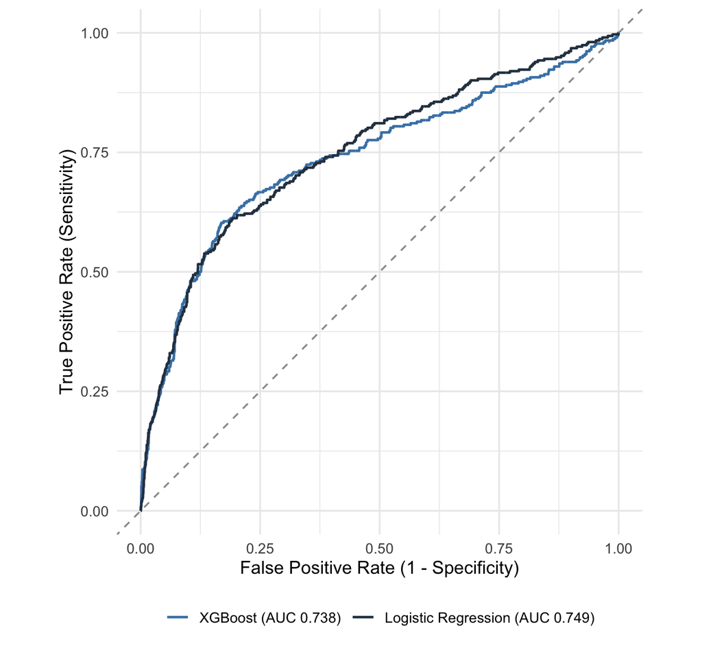

XGBoost Figure 1. Out-of-fold ROC curves for XGBoost and logistic regression (first repeat of stratified 5-fold CV). Every prediction comes from a model that did not see that person. The dashed line is a model with no skill (AUC 0.5).

```r
# Out-of-fold predictions from the first CV repeat, so each person gets one honest prediction
oof_pred <- function(fit_predict, r = 1) {
  oof <- numeric(length(y))
  for (te in folds[[r]]) {
    tr <- setdiff(seq_along(y), te)
    oof[te] <- fit_predict(X[tr, , drop = FALSE], y[tr], X[te, , drop = FALSE])
  }
  oof
}
roc_df <- function(p, model) {       # sensitivity and 1 - specificity at every threshold
  o <- order(p, decreasing = TRUE); yo <- y[o]
  data.frame(model = model,
             fpr = c(0, cumsum(yo == 0) / sum(y == 0)),
             tpr = c(0, cumsum(yo == 1) / sum(y == 1)))
}
# XGBoost's row subsampling draws random numbers. Save and restore the random-number state so
# this extra fit does not shift the random draws used by the later sections (results stay identical).
rng_state <- .Random.seed
p_xgb <- oof_pred(xgb_fit_predict())
p_lr  <- oof_pred(glm_fit_predict)
assign(".Random.seed", rng_state, envir = globalenv())
lab_xgb <- sprintf("XGBoost (AUC %.3f)", auc_fn(y, p_xgb))
lab_lr  <- sprintf("Logistic Regression (AUC %.3f)", auc_fn(y, p_lr))
roc_all <- rbind(roc_df(p_xgb, lab_xgb), roc_df(p_lr, lab_lr))
roc_all$model <- factor(roc_all$model, levels = c(lab_xgb, lab_lr))

ggplot(roc_all, aes(fpr, tpr, colour = model)) +
  geom_abline(linetype = "dashed", colour = "grey60") +
  geom_step(linewidth = 0.8) +
  scale_colour_manual(values = setNames(c("steelblue", "#2c3e50"), c(lab_xgb, lab_lr))) +
  coord_equal() +
  labs(x = "False Positive Rate (1 - Specificity)", y = "True Positive Rate (Sensitivity)",
       colour = NULL) +
  theme_minimal(base_size = 12) +
  theme(legend.position = "bottom")
```

### 5. Does sex modify the alcohol association?

XGBoost has no coefficient to test, so effect modification is assessed by **forbidding** the interaction and checking whether predictions get worse. Using `interaction_constraints`, one model is not allowed to put `male` and any alcohol variable in the same tree branch. If sex really changes how alcohol relates to CKD, blocking that interaction should hurt out-of-fold log-loss.

The same is done for sex × smoking (secondary question).

```r
# Groups of features allowed to interact.
block_sets <- function(block) {
  idx0 <- function(v) match(v, colnames(X)) - 1L   # xgboost wants 0-based column indices
  list(idx0(setdiff(colnames(X), "male")), idx0(setdiff(colnames(X), block)))
}

res_alc <- cv_eval(xgb_fit_predict(list(interaction_constraints = block_sets(alc_vars))))
res_smk <- cv_eval(xgb_fit_predict(list(interaction_constraints = block_sets(smoke_vars))))
res_free <- res[["XGBoost"]]

delta <- data.frame(
  Test = c("Block sex x alcohol", "Block sex x smoking"),
  `Mean log-loss increase when blocked` = c(mean(res_alc$logloss - res_free$logloss),
                                            mean(res_smk$logloss - res_free$logloss)),
  `Repeats where blocking was worse` = c(sprintf("%d / %d", sum(res_alc$logloss > res_free$logloss), n_rep),
                                         sprintf("%d / %d", sum(res_smk$logloss > res_free$logloss), n_rep)),
  `Mean AUC change` = c(mean(res_alc$AUC - res_free$AUC), mean(res_smk$AUC - res_free$AUC)),
  check.names = FALSE
)
kable(delta, digits = 5, caption = "Effect of forbidding sex interactions (constrained minus unconstrained, out-of-fold). Positive log-loss increase = the interaction was useful.")
```

Effect of forbidding sex interactions (constrained minus unconstrained, out-of-fold). Positive log-loss increase = the interaction was useful.

| Test | Mean log-loss increase when blocked | Repeats where blocking was worse | Mean AUC change |
| --- | --- | --- | --- |
| Block sex x alcohol | 0.00014 | 4 / 5 | -0.00056 |
| Block sex x smoking | 0.00015 | 3 / 5 | 0.00068 |

```r
d1 <- delta[[2]][1]
cat(if (d1 > 0.001 && sum(res_alc$logloss > res_free$logloss) == n_rep)
      "**Reading:** blocking sex x alcohol consistently worsened out-of-fold log-loss, which supports effect modification by sex."
    else
      "**Reading:** blocking sex x alcohol made little or no difference to out-of-fold log-loss, so XGBoost finds no extra predictive information in a sex-specific alcohol effect. This does not prove there is no interaction (about 300 CKD cases gives limited power) and should be compared with the likelihood-ratio test from the logistic regression.")
```

**Reading:** blocking sex x alcohol made little or no difference to out-of-fold log-loss, so XGBoost finds no extra predictive information in a sex-specific alcohol effect. This does not prove there is no interaction (about 300 CKD cases gives limited power) and should be compared with the likelihood-ratio test from the logistic regression.

The repeats share one dataset, so they are not independent replicates. Treat this as descriptive evidence, not a formal hypothesis test.

### 6. What drives the predictions? (SHAP)

SHAP values split each person’s predicted CKD log-odds into contributions from each variable. The final model is fitted on all data with the tuned settings.

```r
final <- xgb.train(best_params, dall, nrounds = best_rounds, verbose = 0)

# SHAP values via xgboost's built-in TreeSHAP (the argument differs between xgboost versions)
attempts <- list(
  function() predict(final, dall, predcontrib = TRUE),
  function() predict(final, X, predcontrib = TRUE),
  function() predict(final, dall, type = "contrib"),
  function() predict(final, X, type = "contrib")
)
S <- NULL
for (f in attempts) {
  out <- tryCatch(as.matrix(f()), error = function(e) NULL)
  if (!is.null(out) && nrow(out) == nrow(X) && ncol(out) >= ncol(X)) { S <- out; break }
}
if (is.null(S)) stop("No SHAP output. xgboost version: ", packageVersion("xgboost"))
S <- S[, seq_len(ncol(X)), drop = FALSE]   # variables come first; drop the intercept column
colnames(S) <- colnames(X)

imp <- sort(colMeans(abs(S)), decreasing = TRUE)
```

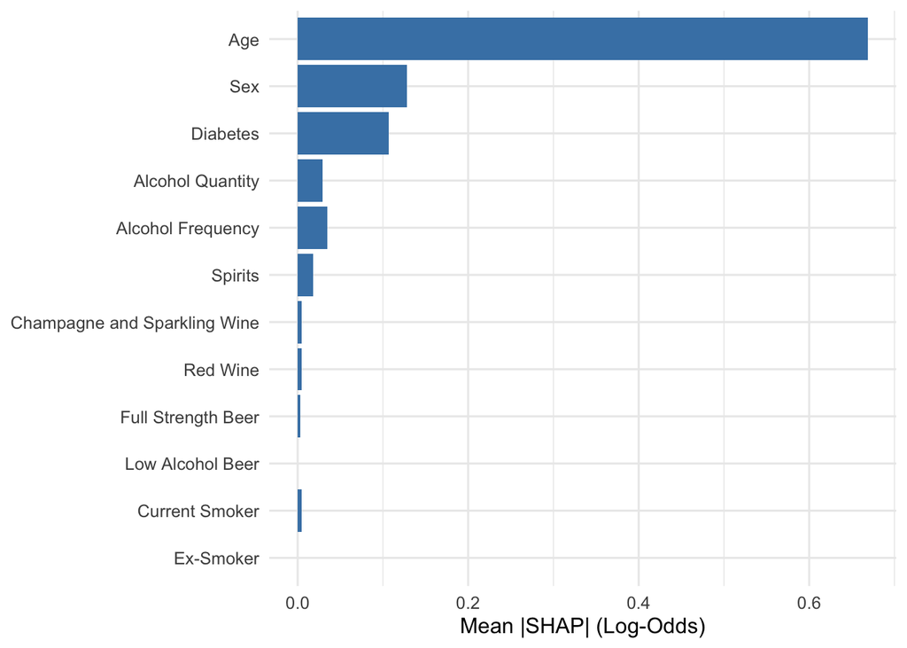

XGBoost Figure 2. Mean absolute SHAP value per variable (importance on the log-odds scale). XGBoost, n = all adults 35+. Correlated beverage columns share credit, so individual beverage bars understate beverage type as a whole (see XGBoost Table 4).

```r
imp_df <- data.frame(var = names(imp), importance = imp) %>%
  slice_head(n = 12) %>%                                   # 12 most important variables
  mutate(var = factor(var, levels = c(setdiff(var_order, bev_cols)[1:5],           # Age, Sex, Diabetes, Quantity, Frequency
                                      bev_cols[order(-imp[bev_cols])],             # beverages, most important first
                                      smoke_vars))) %>%                            # then smoking
  arrange(var) %>%
  mutate(label = factor(labels[as.character(var)], levels = rev(labels[as.character(var)])))
ggplot(imp_df, aes(importance, label)) +
  geom_col(fill = "steelblue") +
  labs(x = "Mean |SHAP| (Log-Odds)", y = NULL) +
  theme_minimal(base_size = 12)
```

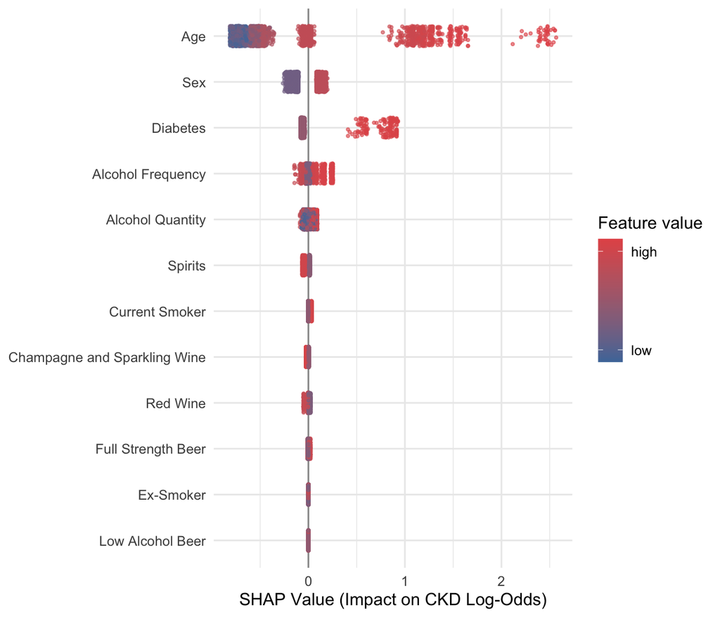

XGBoost Figure 3. SHAP values per person for the 12 most important variables. Each point is one person; colour is the person’s own value of that variable (rank-scaled within variable).

```r
top <- names(imp)[1:12]
long <- do.call(rbind, lapply(top, function(v) {
  data.frame(var = v, shap = S[, v],
             value = rank(X[, v], ties.method = "average") / length(y))
}))
long$label <- factor(labels[long$var], levels = rev(labels[top]))
set.seed(1)
ggplot(long, aes(shap, label, colour = value)) +
  geom_vline(xintercept = 0, colour = "grey60") +
  geom_jitter(height = 0.22, size = 0.7, alpha = 0.6) +
  scale_colour_gradient(low = "#4C78A8", high = "#E45756", name = "Feature value",
                        breaks = c(0.1, 0.9), labels = c("low", "high")) +
  labs(x = "SHAP Value (Impact on CKD Log-Odds)", y = NULL) +
  theme_minimal(base_size = 12)
```

```r
grp <- list(
  "Age"                         = "AGE",
  "Sex"                         = "male",
  "Alcohol quantity"            = "alcohol_quantity",
  "Alcohol frequency (3+ drinks)" = "ALC_freq_3",
  "Beverage type (13 flags)"    = bev_cols,
  "Smoking (2 variables)"       = smoke_vars,
  "Diabetes"                    = "diabetes"
)
grp_tab <- data.frame(Group = names(grp),
                      `Mean |SHAP| (summed)` = sapply(grp, function(v) sum(colMeans(abs(S[, v, drop = FALSE]))))
                      , check.names = FALSE, row.names = NULL)
grp_tab <- grp_tab[order(-grp_tab[[2]]), ]
kable(grp_tab, digits = 4, caption = "XGBoost Table 4. Grouped SHAP importance. Summing over related columns avoids the dilution that correlated beverage flags cause for single-variable importance.")
```

XGBoost Table 4. Grouped SHAP importance. Summing over related columns avoids the dilution that correlated beverage flags cause for single-variable importance.

|  | Group | Mean \|SHAP\| (summed) |
| --- | --- | --- |
| 1 | Age | 0.6687 |
| 2 | Sex | 0.1285 |
| 7 | Diabetes | 0.1065 |
| 4 | Alcohol frequency (3+ drinks) | 0.0350 |
| 5 | Beverage type (13 flags) | 0.0302 |
| 3 | Alcohol quantity | 0.0291 |
| 6 | Smoking (2 variables) | 0.0051 |

#### Alcohol effect by sex

If sex modifies the alcohol association, the alcohol SHAP curve should differ between males and females.

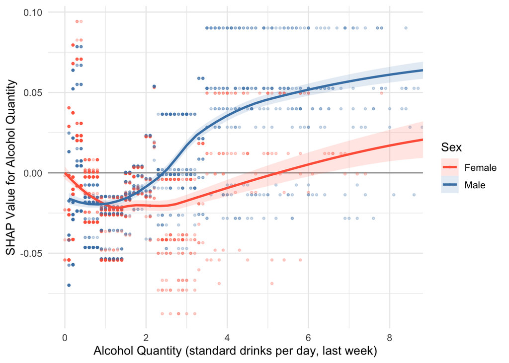

XGBoost Figure 4. SHAP contribution of alcohol quantity (last week) to CKD log-odds, by sex. Points are individuals; lines are loess smooths with 95% bands. Separated or diverging lines suggest sex-specific alcohol effects; overlapping lines suggest none. Interpret the right-hand tail cautiously: few people drink heavily.

```r
sh <- data.frame(alcohol = X[, "alcohol_quantity"], shap = S[, "alcohol_quantity"],
                 Sex = factor(ifelse(X[, "male"] == 1, "Male", "Female")))
ggplot(sh, aes(alcohol, shap, colour = Sex, fill = Sex)) +
  geom_hline(yintercept = 0, colour = "grey60") +
  geom_point(alpha = 0.25, size = 0.8) +
  geom_smooth(method = "loess", span = 0.9, se = TRUE, alpha = 0.15) +
  scale_colour_manual(values = sex_cols) +
  scale_fill_manual(values = sex_cols) +
  coord_cartesian(xlim = c(0, quantile(sh$alcohol, 0.98))) +
  labs(x = "Alcohol Quantity (standard drinks per day, last week)",
       y = "SHAP Value for Alcohol Quantity") +
  theme_minimal(base_size = 12)
```

#### Smoking effect by sex (secondary question)

If sex modifies the smoking association, the smoking SHAP values should differ between males and females within each smoking group.

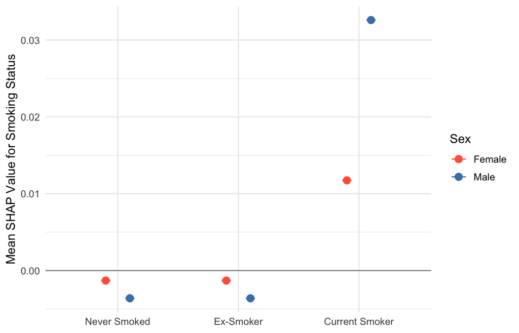

XGBoost Figure 5. Mean SHAP contribution of smoking status to CKD log-odds, by sex. Each person’s smoking contribution is the sum of the current-smoker and ex-smoker SHAP values. Points are group means and bars are 95% confidence intervals. Similar points for males and females within a group suggest no sex-specific smoking effect.

```r
smk <- data.frame(
  shap   = S[, "smoker_current"] + S[, "smoker_ex"],     # total contribution of smoking status
  Status = factor(ifelse(X[, "smoker_current"] == 1, "Current Smoker",
                  ifelse(X[, "smoker_ex"] == 1, "Ex-Smoker", "Never Smoked")),
                  levels = c("Never Smoked", "Ex-Smoker", "Current Smoker")),
  Sex    = factor(ifelse(X[, "male"] == 1, "Male", "Female")))
smk_sum <- smk %>%
  group_by(Status, Sex) %>%
  summarise(n = n(), mean = mean(shap), se = sd(shap) / sqrt(n), .groups = "drop") %>%
  mutate(lo = mean - 1.96 * se, hi = mean + 1.96 * se)

ggplot(smk_sum, aes(Status, mean, colour = Sex)) +
  geom_hline(yintercept = 0, colour = "grey60") +
  geom_errorbar(aes(ymin = lo, ymax = hi), width = 0.15, position = position_dodge(width = 0.4)) +
  geom_point(size = 3, position = position_dodge(width = 0.4)) +
  scale_colour_manual(values = sex_cols) +
  labs(x = NULL, y = "Mean SHAP Value for Smoking Status") +
  theme_minimal(base_size = 12)
```

### Reproducibility

XGBoost analysis run in R 4.6.1 with xgboost 3.2.1.1, with fixed random seeds for the cross-validation folds and model fitting.